# Assessment2

Meral Erdogan - 4634311

01 09 2021

## Name: *Meral Isitir Erdogan*

## Student ID: **4634311**

# Assignment 2

### Part 2: Data Wrangling and visualization

```r
# R libraries to use, load below libraries
library(tidyverse)
library(skimr)
library(knitr)
library(janitor)
```

```r
library(ggplot2)
```

### Part 2 - Reading Data

```r
# Read data

data <- read_csv('https://raw.githubusercontent.com/rfordatascience/tidytuesday/master/data/2018/2018-11-20/thanksgiving_meals.csv')
```

### Part 2 - Question 1 - Using kable function to show first 10 rows

```r
kable(data[1:10, ])
```

| id | celebrate | main_dish | main_dish_other | main_prep | main_prep_other | stuffing | stuffing_other | cranberry | cranberry_other | gravy | side1 | side2 | side3 | side4 | side5 | side6 | side7 | side8 | side9 | side10 | side11 | side12 | side13 | side14 | side15 | pie1 | pie2 | pie3 | pie4 | … |
| --- | --- | --- | --- | --- | --- | --- | --- | --- | --- | --- | --- | --- | --- | --- | --- | --- | --- | --- | --- | --- | --- | --- | --- | --- | --- | --- | --- | --- | --- | --- |
| 4337954960 | Yes | Turkey | NA | Baked | NA | Bread-based | NA | None | NA | Yes | NA | Carrots | NA | NA | NA | NA | Green beans/green bean casserole | Macaroni and cheese | Mashed potatoes | NA | NA | NA | Yams/sweet potato casserole | NA | NA | Apple | NA | NA | NA | … |
| 4337951949 | Yes | Turkey | NA | Baked | NA | Bread-based | NA | Other (please specify) | Homemade cranberry gelatin ring | Yes | NA | NA | NA | Corn | NA | NA | Green beans/green bean casserole | Macaroni and cheese | Mashed potatoes | Rolls/biscuits | NA | Vegetable salad | Yams/sweet potato casserole | Other (please specify) | Asian vinagrette salad | Apple | NA | NA | Chocolate | … |
| 4337935621 | Yes | Turkey | NA | Roasted | NA | Rice-based | NA | Homemade | NA | Yes | Brussel sprouts | Carrots | Cauliflower | Corn | Cornbread | NA | NA | NA | Mashed potatoes | Rolls/biscuits | NA | Vegetable salad | NA | NA | NA | Apple | NA | Cherry | NA | … |
| 4337933040 | Yes | Turkey | NA | Baked | NA | Bread-based | NA | Homemade | NA | Yes | Brussel sprouts | NA | NA | NA | Cornbread | NA | NA | NA | Mashed potatoes | Rolls/biscuits | NA | Vegetable salad | Yams/sweet potato casserole | NA | NA | NA | NA | NA | NA | … |
| 4337931983 | Yes | Tofurkey | NA | Baked | NA | Bread-based | NA | Canned | NA | Yes | Brussel sprouts | NA | NA | NA | Cornbread | NA | NA | NA | Mashed potatoes | Rolls/biscuits | Squash | Vegetable salad | Yams/sweet potato casserole | NA | NA | Apple | NA | NA | NA | … |
| 4337929779 | Yes | Turkey | NA | Roasted | NA | Rice-based | NA | Homemade | NA | Yes | Brussel sprouts | Carrots | Cauliflower | Corn | Cornbread | Fruit salad | Green beans/green bean casserole | Macaroni and cheese | Mashed potatoes | Rolls/biscuits | Squash | Vegetable salad | Yams/sweet potato casserole | NA | NA | NA | NA | NA | NA | … |
| 4337924420 | Yes | Turkey | NA | Baked | NA | Bread-based | NA | Canned | NA | Yes | NA | NA | NA | NA | NA | Fruit salad | Green beans/green bean casserole | NA | Mashed potatoes | Rolls/biscuits | NA | NA | Yams/sweet potato casserole | NA | NA | Apple | NA | NA | NA | … |
| 4337916002 | Yes | Turkey | NA | Baked | NA | Rice-based | NA | Homemade | NA | Yes | NA | Carrots | NA | NA | NA | NA | NA | NA | NA | NA | NA | NA | NA | NA | NA | NA | NA | NA | Chocolate | … |
| 4337914977 | Yes | Turkey | NA | Roasted | NA | Bread-based | NA | Canned | NA | Yes | Brussel sprouts | NA | NA | Corn | Cornbread | NA | Green beans/green bean casserole | NA | Mashed potatoes | Rolls/biscuits | Squash | NA | NA | NA | NA | Apple | Buttermilk | NA | NA | … |
| 4337899817 | Yes | Other (please specify) | Turkey and Ham | Baked | NA | Bread-based | NA | Other (please specify) | Both Canned and Homemade | Yes | Brussel sprouts | Carrots | NA | NA | NA | NA | Green beans/green bean casserole | NA | Mashed potatoes | Rolls/biscuits | NA | NA | Yams/sweet potato casserole | NA | NA | NA | Buttermilk | NA | NA | … |

### Part 2 - Question 2 - Using skim function to show the summary of variables

```r
data%>%
skim()
```

Data summary

| Name | Piped data |
| --- | --- |
| Number of rows | 1058 |
| Number of columns | 65 |
| _______________________ |  |
| Column type frequency: |  |
| character | 64 |
| numeric | 1 |
| ________________________ |  |
| Group variables | None |

**Variable type: character**

| skim_variable | n_missing | complete_rate | min | max | empty | n_unique | whitespace |
| --- | --- | --- | --- | --- | --- | --- | --- |
| celebrate | 0 | 1.00 | 2 | 3 | 0 | 2 | 0 |
| main_dish | 84 | 0.92 | 6 | 22 | 0 | 8 | 0 |
| main_dish_other | 1023 | 0.03 | 4 | 85 | 0 | 32 | 0 |
| main_prep | 84 | 0.92 | 5 | 22 | 0 | 5 | 0 |
| main_prep_other | 1007 | 0.05 | 1 | 33 | 0 | 32 | 0 |
| stuffing | 84 | 0.92 | 4 | 22 | 0 | 4 | 0 |
| stuffing_other | 1022 | 0.03 | 4 | 46 | 0 | 29 | 0 |
| cranberry | 84 | 0.92 | 4 | 22 | 0 | 4 | 0 |
| cranberry_other | 1033 | 0.02 | 3 | 61 | 0 | 24 | 0 |
| gravy | 84 | 0.92 | 2 | 3 | 0 | 2 | 0 |
| side1 | 903 | 0.15 | 15 | 15 | 0 | 1 | 0 |
| side2 | 816 | 0.23 | 7 | 7 | 0 | 1 | 0 |
| side3 | 970 | 0.08 | 11 | 11 | 0 | 1 | 0 |
| side4 | 594 | 0.44 | 4 | 4 | 0 | 1 | 0 |
| side5 | 823 | 0.22 | 9 | 9 | 0 | 1 | 0 |
| side6 | 843 | 0.20 | 11 | 11 | 0 | 1 | 0 |
| side7 | 372 | 0.65 | 32 | 32 | 0 | 1 | 0 |
| side8 | 852 | 0.19 | 19 | 19 | 0 | 1 | 0 |
| side9 | 241 | 0.77 | 15 | 15 | 0 | 1 | 0 |
| side10 | 292 | 0.72 | 14 | 14 | 0 | 1 | 0 |
| side11 | 887 | 0.16 | 6 | 6 | 0 | 1 | 0 |
| side12 | 849 | 0.20 | 15 | 15 | 0 | 1 | 0 |
| side13 | 427 | 0.60 | 27 | 27 | 0 | 1 | 0 |
| side14 | 947 | 0.10 | 22 | 22 | 0 | 1 | 0 |
| side15 | 947 | 0.10 | 4 | 78 | 0 | 89 | 0 |
| pie1 | 544 | 0.49 | 5 | 5 | 0 | 1 | 0 |
| pie2 | 1023 | 0.03 | 10 | 10 | 0 | 1 | 0 |
| pie3 | 945 | 0.11 | 6 | 6 | 0 | 1 | 0 |
| pie4 | 925 | 0.13 | 9 | 9 | 0 | 1 | 0 |
| pie5 | 1022 | 0.03 | 13 | 13 | 0 | 1 | 0 |
| pie6 | 1019 | 0.04 | 8 | 8 | 0 | 1 | 0 |
| pie7 | 1024 | 0.03 | 5 | 5 | 0 | 1 | 0 |
| pie8 | 716 | 0.32 | 5 | 5 | 0 | 1 | 0 |
| pie9 | 329 | 0.69 | 7 | 7 | 0 | 1 | 0 |
| pie10 | 906 | 0.14 | 12 | 12 | 0 | 1 | 0 |
| pie11 | 1018 | 0.04 | 4 | 4 | 0 | 1 | 0 |
| pie12 | 987 | 0.07 | 22 | 22 | 0 | 1 | 0 |
| pie13 | 987 | 0.07 | 5 | 46 | 0 | 61 | 0 |
| dessert1 | 948 | 0.10 | 13 | 13 | 0 | 1 | 0 |
| dessert2 | 1042 | 0.02 | 8 | 8 | 0 | 1 | 0 |
| dessert3 | 930 | 0.12 | 8 | 8 | 0 | 1 | 0 |
| dessert4 | 986 | 0.07 | 11 | 11 | 0 | 1 | 0 |
| dessert5 | 867 | 0.18 | 10 | 10 | 0 | 1 | 0 |
| dessert6 | 854 | 0.19 | 7 | 7 | 0 | 1 | 0 |
| dessert7 | 1015 | 0.04 | 5 | 5 | 0 | 1 | 0 |
| dessert8 | 792 | 0.25 | 9 | 9 | 0 | 1 | 0 |
| dessert9 | 955 | 0.10 | 13 | 13 | 0 | 1 | 0 |
| dessert10 | 763 | 0.28 | 4 | 4 | 0 | 1 | 0 |
| dessert11 | 924 | 0.13 | 22 | 22 | 0 | 1 | 0 |
| dessert12 | 924 | 0.13 | 3 | 59 | 0 | 92 | 0 |
| prayer | 99 | 0.91 | 2 | 3 | 0 | 2 | 0 |
| travel | 107 | 0.90 | 59 | 80 | 0 | 4 | 0 |
| watch_program | 556 | 0.47 | 13 | 13 | 0 | 1 | 0 |
| kids_table_age | 107 | 0.90 | 2 | 13 | 0 | 12 | 0 |
| hometown_friends | 107 | 0.90 | 2 | 3 | 0 | 2 | 0 |
| friendsgiving | 107 | 0.90 | 2 | 3 | 0 | 2 | 0 |
| black_friday | 107 | 0.90 | 2 | 3 | 0 | 2 | 0 |
| work_retail | 107 | 0.90 | 2 | 3 | 0 | 2 | 0 |
| work_black_friday | 988 | 0.07 | 2 | 13 | 0 | 3 | 0 |
| community_type | 110 | 0.90 | 5 | 8 | 0 | 3 | 0 |
| age | 33 | 0.97 | 3 | 7 | 0 | 4 | 0 |
| gender | 33 | 0.97 | 4 | 6 | 0 | 2 | 0 |
| family_income | 33 | 0.97 | 12 | 20 | 0 | 11 | 0 |
| us_region | 59 | 0.94 | 7 | 18 | 0 | 9 | 0 |

**Variable type: numeric**

| skim_variable | n_missing | complete_rate | mean | sd | p0 | p25 | p50 | p75 | p100 | hist |
| --- | --- | --- | --- | --- | --- | --- | --- | --- | --- | --- |
| id | 0 | 1 | 4336731188 | 493783.4 | 4335894916 | 4336339486 | 4336796628 | 4337012140 | 4337954960 | ▅▃▇▂▂ |

### Part 2 - Explanation for Question 2

what variables may be useful? Parameters might be useful to predict family income • main_dish • main_prep • stuffing • gravy • Number and type of side, pie and dessert

To be able to predict the family income based on their menu main_dish, main_prep, stuffing, gravy, number and type of side , pie and desserts might be useful parameters. Rich people may have different main dish and preparation for their main dish whereas middle income people and poor people might have different main dish and main dish preparation choice. Similarly stuffing and gravy might be different according to income. Also the number and choice of side dishes, pies and desserts might be different according to family income. From this data set to be able to use type and number of side, pie and dessert we should do some data work, otherwise there are too many columns with NA answers. Since it is Thanksgiving, which is special for everyone and tradition to have turkey almost everybody has turkey as main dish.

Are all of them correct type? No, some of them may not be correct type. We should analyse and see if there is any relation between family income and their choices related with Thanksgiving menu.

We can use same variables to predict community type and US_region as well. Rich people may choose to live in similar community types and similar region of the USA. Menu choices can give us prediction about family income, community type and US region. If they are having big and fancy Thanks giving meals then most probably their income level is high, they live in good suburbs, and good regions of the USA. Also, type of side dish, pie and dessert might give idea for regions of USA, for example apple pie or pumpkin pie might be popular in certain parts of the USA, but some other parts might prefer to eat pecan pie etc.

Some of the parameters might not be correct types. We should analyse and see if there is any relation between USA region, community type and their menu choices related with Thanksgiving menu.

### Part 2 - Question 3 Using `fct_reorder` and `parse_number` functions

```r
data%>%
mutate(family_income = fct_reorder(family_income, parse_number(family_income)))%>%
filter(family_income != "Prefer not to answer")%>%
mutate(family_income=as_factor(family_income))
```

```
## # A tibble: 889 x 65
##        id celebrate main_dish main_dish_other main_prep main_prep_other stuffing
##     <dbl> <chr>     <chr>     <chr>           <chr>     <chr>           <chr>
##  1 4.34e9 Yes       Turkey    <NA>            Baked     <NA>            Bread-b~
##  2 4.34e9 Yes       Turkey    <NA>            Baked     <NA>            Bread-b~
##  3 4.34e9 Yes       Turkey    <NA>            Roasted   <NA>            Rice-ba~
##  4 4.34e9 Yes       Turkey    <NA>            Baked     <NA>            Bread-b~
##  5 4.34e9 Yes       Tofurkey  <NA>            Baked     <NA>            Bread-b~
##  6 4.34e9 Yes       Turkey    <NA>            Roasted   <NA>            Rice-ba~
##  7 4.34e9 Yes       Turkey    <NA>            Baked     <NA>            Bread-b~
##  8 4.34e9 Yes       Turkey    <NA>            Roasted   <NA>            Bread-b~
##  9 4.34e9 Yes       Other (p~ Turkey and Ham  Baked     <NA>            Bread-b~
## 10 4.34e9 No        <NA>      <NA>            <NA>      <NA>            <NA>
## # ... with 879 more rows, and 58 more variables: stuffing_other <chr>,
## #   cranberry <chr>, cranberry_other <chr>, gravy <chr>, side1 <chr>,
## #   side2 <chr>, side3 <chr>, side4 <chr>, side5 <chr>, side6 <chr>,
## #   side7 <chr>, side8 <chr>, side9 <chr>, side10 <chr>, side11 <chr>,
## #   side12 <chr>, side13 <chr>, side14 <chr>, side15 <chr>, pie1 <chr>,
## #   pie2 <chr>, pie3 <chr>, pie4 <chr>, pie5 <chr>, pie6 <chr>, pie7 <chr>,
## #   pie8 <chr>, pie9 <chr>, pie10 <chr>, pie11 <chr>, pie12 <chr>, ...
```

### Part 2 - Question 4 number of people who celebrate

```r
data%>%
count (celebrate )
```

```
## # A tibble: 2 x 2
##   celebrate     n
##   <chr>     <int>
## 1 No           78
## 2 Yes         980
```

980 people celebrates the Thanksgiving and they said “Yes”.

### Part 2 - Question 5 categories and insights for each main dish served and the method it is prepared

```r
data%>%
count (main_dish, main_prep, sort = TRUE)
```

```
## # A tibble: 31 x 3
##    main_dish              main_prep                  n
##    <chr>                  <chr>                  <int>
##  1 Turkey                 Baked                    422
##  2 Turkey                 Roasted                  351
##  3 <NA>                   <NA>                      84
##  4 Turkey                 Fried                     41
##  5 Turkey                 Other (please specify)    34
##  6 Ham/Pork               Baked                     22
##  7 Other (please specify) Baked                     16
##  8 Tofurkey               Baked                     14
##  9 Other (please specify) Other (please specify)    12
## 10 Turkey                 I don't know              11
## # ... with 21 more rows
```

There are 9 different answers for the main dish but vast majority said they have turkey for Thanksgiving meal. For preparation method there are 6 different answers given and majority said they bake or roast their meal. When I check main dish and preparation method together there are 31 options but vast majority said they have “baked turkey” or “roasted turkey”.

### Part 2 - Question 6 Data viz showing insights for main dish served and the method used

```r
# Load below libraries
library(scales)
library(lubridate)
```

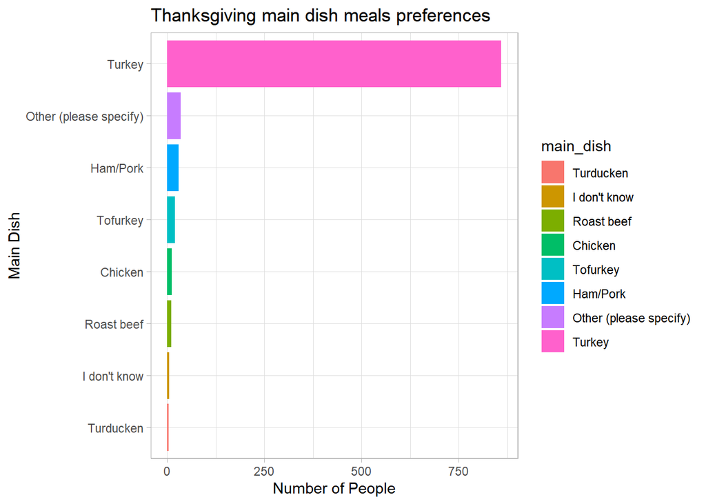

```r
#6 first data visualization

theme_set(theme_light())

data%>%
count(main_dish, sort = TRUE) %>%
filter(main_dish != "NA") %>%
mutate(main_dish = fct_reorder(main_dish, n)) %>%
ggplot(aes(n, main_dish, fill= main_dish)) +
  geom_col() +
  labs(x = "Number of People",
       y = "Main Dish",
       title = "Thanksgiving main dish meals preferences")
```

Explanation: First data visualization shows the number of people main dish preferences for the Thanksgiving, it looks like vast majority has turkey for Thanksgiving meal. Since it is the tradition to have turkey for Thanksgiving, data visualization looks as expected.

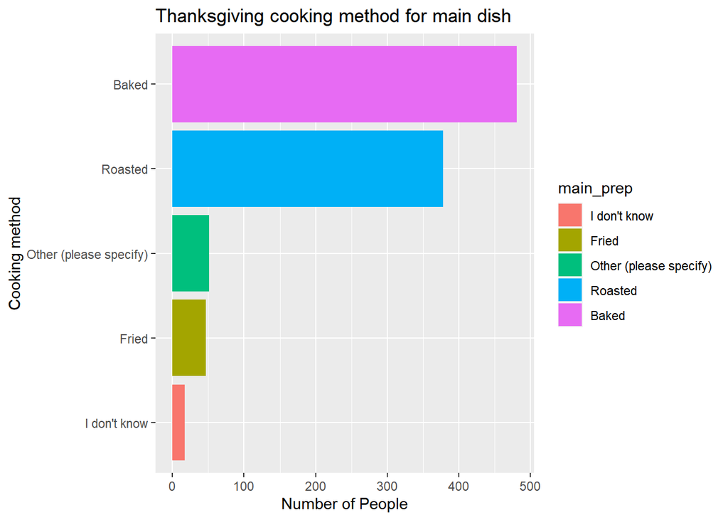

```r
#6 second data visualization

theme_set(theme_gray())

data%>%
count(main_prep, sort = TRUE) %>%
filter(main_prep != "NA") %>%
mutate(main_prep = fct_reorder(main_prep, n)) %>%
ggplot(aes(n, main_prep, fill=main_prep)) +
  geom_col() +
  labs(x = "Number of People",
       y = "Cooking method",
       title = "Thanksgiving cooking method for main dish")
```

Explanation: Second data visualization shows the number of cooking method for Thanksgiving meal, from this visualization we see that mainly people choose to bake or roast their dish for Thanksgiving.Very few people choose to fry their main dish.

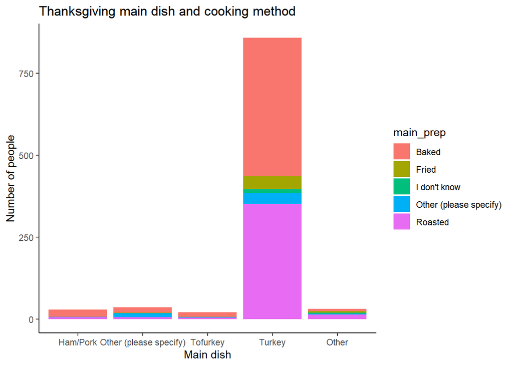

```r
#6 third data visualization

theme_set(theme_classic())

data%>%
mutate(main_dish = fct_lump(main_dish, 4)) %>%
group_by(main_dish)%>%
filter(main_prep != "NA" & main_dish != "NA") %>%
ggplot(aes(main_dish, fill=main_prep)) +
  geom_bar()+
 labs(x = "Main dish",
       y = "Number of people",
       title = "Thanksgiving main dish and cooking method")
```

Explanation: Third data visualization shows the distribution of main dish and their cooking method. We see that people choose turkey for main dish and they either bake or roast their turkey. Very few people fry their turkey or they did not say how they cook.

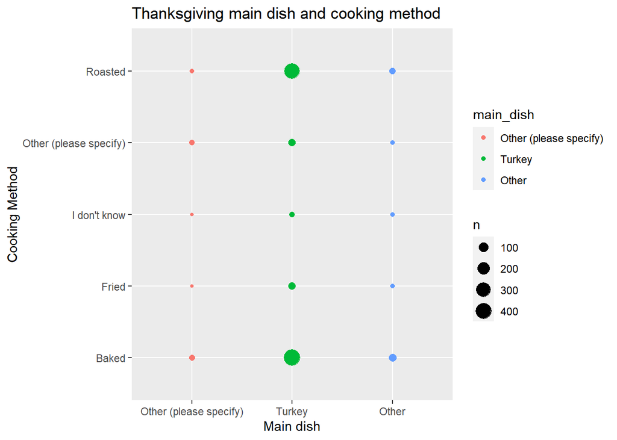

```r
#6 fourth data visualization

theme_set(theme_gray())

data%>%
mutate(main_dish = fct_lump(main_dish, 2)) %>%
group_by(main_dish)%>%
filter(main_prep != "NA" & main_dish != "NA") %>%
ggplot(aes(main_dish, main_prep, color=main_dish)) +
  geom_count()+
  labs(x = "Main dish",
       y = "Cooking Method",
       title = "Thanksgiving main dish and cooking method")
```

Explanation: Fourth data visualization is very similar to third visualization. It shows the distribution of main dish and their cooking method with different visual elements. Rather than using bars to show numbers this shows with the circles. But we see that both roasted turkey or baked turkey have circles around 400 in size, baked turkey is little bit bigger than roasted turkey, and it was the highest which is 422.

### Part 2 - Question 7 number of cranberry sauce and number of gravy

```r
data%>%
count(cranberry)
```

```
## # A tibble: 5 x 2
##   cranberry                  n
##   <chr>                  <int>
## 1 Canned                   502
## 2 Homemade                 301
## 3 None                     146
## 4 Other (please specify)    25
## 5 <NA>                      84
```

```r
data%>%
count(gravy)
```

```
## # A tibble: 3 x 2
##   gravy     n
##   <chr> <int>
## 1 No       82
## 2 Yes     892
## 3 <NA>     84
```

For cranberry; 502 people used canned cranberry, 301 people used homemade cranberry and 25 people used other cranberry sauce, which makes 828 people used cranberry sauce. For gravy 892 people said they used gravy.

### Part 2 - Question 8 Data Visualization for distribution of those who celebrate across income ranges

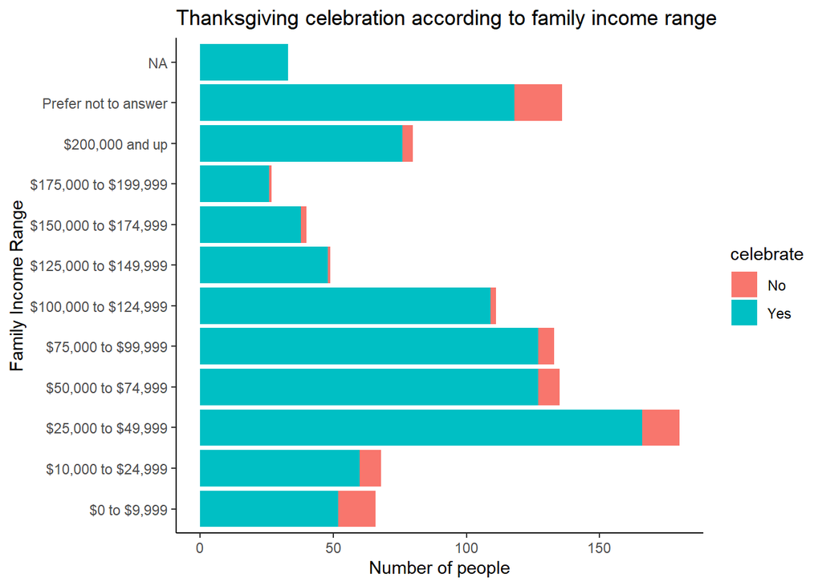

```r
theme_set(theme_classic())

data%>%
mutate(family_income = fct_reorder(family_income, parse_number(family_income)))%>%
ggplot(aes(family_income, fill=celebrate )) +
geom_bar()+
coord_flip()+
labs(x = "Family Income Range",
     y = "Number of people",
    title = "Thanksgiving celebration according to family income range")
```

### Part 2 - Question 9 is missing

### Part 2 - Question 10 Using the Provided Code

```r
newdata <- data %>%
select(id, starts_with("side"),
         starts_with("pie"),
         starts_with("dessert")) %>%
  select(-side15, -pie13, -dessert12) %>%
  gather(type, value, -id) %>%
  filter(!is.na(value),
         !value %in% c("None", "Other (please specify)")) %>%
  mutate(type = str_remove(type, "\\d+"))
```

### Part 2 - Question 11 Using `pairwise_cor()` function

```r
#install package and load library
#install.packages("widyr")
library(widyr)
newdata%>%
pairwise_cor(value, id, sort = TRUE)
```

```
## # A tibble: 992 x 3
##    item1               item2               correlation
##    <chr>               <chr>                     <dbl>
##  1 Cookies             Brownies                  0.411
##  2 Brownies            Cookies                   0.411
##  3 Sweet Potato        Macaroni and cheese       0.365
##  4 Macaroni and cheese Sweet Potato              0.365
##  5 Rolls/biscuits      Mashed potatoes           0.341
##  6 Mashed potatoes     Rolls/biscuits            0.341
##  7 Peach cobbler       Sweet Potato              0.339
##  8 Sweet Potato        Peach cobbler             0.339
##  9 Pumpkin             Mashed potatoes           0.290
## 10 Mashed potatoes     Pumpkin                   0.290
## # ... with 982 more rows
```

Explanation: Pairwise correlation finds the correlations of pairs of items in a column. We can check if there is any relation between items. For example, in our data set we can search if cookies goes with brownies, if they are related with each other. Maybe ice cream is eaten with brownies because they go well together. We can check with this function. It helps us to see if they are correlated or not by using their unique ID number.

When I execute the new data set with pairwise_cor I see that Cookies and Brownies are correlated with 0.41, which is the highest correlation and followed by Sweet Potato and Macaroni and cheese. It makes the correlation by using their unique ID.

### Part 2 - Question 13 Building a Model

```r
#load library
library(randomForest)
data<-data%>%
mutate(family_income_number = parse_number(as.character(family_income)))%>%
filter(!is.na(family_income_number))
summary(data)
```

```
##        id             celebrate          main_dish         main_dish_other
##  Min.   :4.336e+09   Length:889         Length:889         Length:889
##  1st Qu.:4.336e+09   Class :character   Class :character   Class :character
##  Median :4.337e+09   Mode  :character   Mode  :character   Mode  :character
##  Mean   :4.337e+09
##  3rd Qu.:4.337e+09
##  Max.   :4.338e+09
##   main_prep         main_prep_other      stuffing         stuffing_other
##  Length:889         Length:889         Length:889         Length:889
##  Class :character   Class :character   Class :character   Class :character
##  Mode  :character   Mode  :character   Mode  :character   Mode  :character
##
##
##
##   cranberry         cranberry_other       gravy              side1
##  Length:889         Length:889         Length:889         Length:889
##  Class :character   Class :character   Class :character   Class :character
##  Mode  :character   Mode  :character   Mode  :character   Mode  :character
##
##
##
##     side2              side3              side4              side5
##  Length:889         Length:889         Length:889         Length:889
##  Class :character   Class :character   Class :character   Class :character
##  Mode  :character   Mode  :character   Mode  :character   Mode  :character
##
##
##
##     side6              side7              side8              side9
##  Length:889         Length:889         Length:889         Length:889
##  Class :character   Class :character   Class :character   Class :character
##  Mode  :character   Mode  :character   Mode  :character   Mode  :character
##
##
##
##     side10             side11             side12             side13
##  Length:889         Length:889         Length:889         Length:889
##  Class :character   Class :character   Class :character   Class :character
##  Mode  :character   Mode  :character   Mode  :character   Mode  :character
##
```

[output cut: 64 more lines]

```
##
##  community_type         age               gender          family_income
##  Length:889         Length:889         Length:889         Length:889
##  Class :character   Class :character   Class :character   Class :character
##  Mode  :character   Mode  :character   Mode  :character   Mode  :character
##
##
##
##   us_region         family_income_number
##  Length:889         Min.   :     0
##  Class :character   1st Qu.: 25000
##  Mode  :character   Median : 50000
##                     Mean   : 74078
##                     3rd Qu.:100000
##                     Max.   :200000
```

```r
Random_forest_result1 <- randomForest(family_income_number~celebrate+main_dish+age+community_type, data=data, na.action = na.omit)
summary(Random_forest_result1)
```

```
##                 Length Class  Mode
## call              4    -none- call
## type              1    -none- character
## predicted       829    -none- numeric
## mse             500    -none- numeric
## rsq             500    -none- numeric
## oob.times       829    -none- numeric
## importance        4    -none- numeric
## importanceSD      0    -none- NULL
## localImportance   0    -none- NULL
## proximity         0    -none- NULL
## ntree             1    -none- numeric
## mtry              1    -none- numeric
## forest           11    -none- list
## coefs             0    -none- NULL
## y               829    -none- numeric
## test              0    -none- NULL
## inbag             0    -none- NULL
## terms             3    terms  call
## na.action        60    omit   numeric
```

```r
Random_forest_result2 <- randomForest(family_income_number~community_type+gender+us_region, data=data, na.action = na.omit)
summary(Random_forest_result2)
```

```
##                 Length Class  Mode
## call              4    -none- call
## type              1    -none- character
## predicted       814    -none- numeric
## mse             500    -none- numeric
## rsq             500    -none- numeric
## oob.times       814    -none- numeric
## importance        3    -none- numeric
## importanceSD      0    -none- NULL
## localImportance   0    -none- NULL
## proximity         0    -none- NULL
## ntree             1    -none- numeric
## mtry              1    -none- numeric
## forest           11    -none- list
## coefs             0    -none- NULL
## y               814    -none- numeric
## test              0    -none- NULL
## inbag             0    -none- NULL
## terms             3    terms  call
## na.action        75    omit   numeric
```

```r
Random_forest_result3 <- randomForest(family_income_number~main_dish+travel+us_region+prayer+age, data=data, na.action = na.omit)

summary(Random_forest_result3)
```

```
##                 Length Class  Mode
## call              4    -none- call
## type              1    -none- character
## predicted       814    -none- numeric
## mse             500    -none- numeric
## rsq             500    -none- numeric
## oob.times       814    -none- numeric
## importance        5    -none- numeric
## importanceSD      0    -none- NULL
## localImportance   0    -none- NULL
## proximity         0    -none- NULL
## ntree             1    -none- numeric
## mtry              1    -none- numeric
## forest           11    -none- list
## coefs             0    -none- NULL
## y               814    -none- numeric
## test              0    -none- NULL
## inbag             0    -none- NULL
## terms             3    terms  call
## na.action        75    omit   numeric
```

Explanation:

In my first model I have used “celebrate”, “main_dish”, “age” and “community_type” variables to predict family income thinking that these variables might affect the family income.

In my second model I have used “community_type”, “gender” and “us_region” variables to predict family income.

In my third model I have used “main_dish”, “travel”, “us_region”, “prayer” and “age” variables to predict family income.

I think first model is the best because it has more prediction than other two models. In first model I had 829 prediction but in the second and third model I had 814 prediction. In first model the number of na.action item which means omitted item is 60, but in second and third model it is 75.